# The Average Goals per Player per Season in the NHL (2008-2018)

# Introduction

The dataset that we used in this report can be found [here](http://inalitic.com/datasets/nhl%20player%20data.html).

# Methods

First, we need to load the dataset, and we can take a look at the first and last few observations and name all of the variables.

```r
skaters_full = read.csv("skater_stats.csv")
head(skaters_full)
```

```
##                       X Season            Player Age    Tm  Pos GP     G    GPG
## 1 2018Justin Abdelkader   2018 Justin Abdelkader  30  DET   LW  75   13  0.1733
## 2      2018Pontus Aberg   2018      Pontus Aberg  24  TOT   LW  53    4  0.0755
## 3      2018Noel Acciari   2018      Noel Acciari  26  BOS    C  60   10  0.1667
## 4    2018Kenny Agostino   2018    Kenny Agostino  25  BOS   LW   5  -    0.0000
## 5     2018Sebastian Aho   2018     Sebastian Aho  20  CAR   RW  78   29  0.3718
## 6     2018Sebastian Aho   2018     Sebastian Aho  21  NYI    D  22    1  0.0455
##      A  PTS X...  PIM   EVG   PPG   SHG   GWG   EVA   PPA   SHA     S    S.
## 1  22   35  -11   78     9     4   -     -      17     5   -     110    12
## 2  12   16    9   10     4   -     -       3    11     1   -      70     6
## 3   1   11   -6    9     9   -       1   -       1   -     -      66    15
## 4   1    1   -1    4   -     -     -     -     -       1   -      11   -
## 5  36   65    4   24    21     8   -       4    28     8   -     200    15
## 6   3    4   -5    6   -       1   -     -       3   -     -      24     4
##       TOI  ATOI BLK HIT FOwin FOloss  FO.
## 1  1,241  16:33  40 174    47     50 48.5
## 2    645  12:10   8  24     4      8 33.3
## 3    775  12:55  41 152    42     51 45.2
## 4     60  12:03   1   4     0      1  0.0
## 5  1,398  17:55  17  65    78     94 45.3
## 6    357  16:15  13  10     0      1  0.0
```

```r
tail(skaters_full)
```

```
##                         X Season          Player Age    Tm  Pos GP    G    GPG
## 37820  1940Bryan Hextall*   1940  Bryan Hextall*  26  NYR   RW  48  24  0.5000
## 37821 1940Gordie Drillon*   1940 Gordie Drillon*  26  TOR   RW  43  21  0.4884
## 37822    1940Bill Cowley*   1940    Bill Cowley*  27  BOS    C  48  13  0.2708
## 37823   1940Woody Dumart*   1940   Woody Dumart*  23  BOS   LW  48  22  0.4583
## 37824    1940Bobby Bauer*   1940    Bobby Bauer*  24  BOS   RW  48  17  0.3542
## 37825   1940Milt Schmidt*   1940   Milt Schmidt*  21  BOS    C  48  22  0.4583
##          A  PTS X...  PIM EVG PPG SHG GWG EVA PPA SHA S S. TOI ATOI BLK HIT
## 37820  15   39        52                                             NA  NA
## 37821  19   40        13                                             NA  NA
## 37822  27   40        24                                             NA  NA
## 37823  21   43        16                                             NA  NA
## 37824  26   43         2                                             NA  NA
## 37825  30   52        37                                             NA  NA
##       FOwin FOloss FO.
## 37820    NA     NA  NA
## 37821    NA     NA  NA
## 37822    NA     NA  NA
## 37823    NA     NA  NA
## 37824    NA     NA  NA
## 37825    NA     NA  NA
```

```r
names(skaters_full)
```

```
##  [1] "X"      "Season" "Player" "Age"    "Tm"     "Pos"    "GP"     "G"
##  [9] "GPG"    "A"      "PTS"    "X..."   "PIM"    "EVG"    "PPG"    "SHG"
## [17] "GWG"    "EVA"    "PPA"    "SHA"    "S"      "S."     "TOI"    "ATOI"
## [25] "BLK"    "HIT"    "FOwin"  "FOloss" "FO."
```

This data set in its entirety is quite large, and encompasses a large time frame, from 1940 until 2018. In order to make this more relevant, we decided to subset the data and only consider observations between 2008 and 2018, as follows.

```r
skaters <- subset(skaters_full, Season >= 2008)
```

Next, looking at the structure of our data frame, we can see that we have:

- a lot of numerical observations that R views as character observations, and
- a lot of empty values within each category, which become NA values once we convert variables to numeric.

```r
str(skaters)
```

```
## 'data.frame':    9684 obs. of  29 variables:
##  $ X     : chr  "2018Justin Abdelkader" "2018Pontus Aberg" "2018Noel Acciari" "2018Kenny Agostino" ...
##  $ Season: int  2018 2018 2018 2018 2018 2018 2018 2018 2018 2018 ...
##  $ Player: chr  "Justin Abdelkader" "Pontus Aberg" "Noel Acciari" "Kenny Agostino" ...
##  $ Age   : int  30 24 26 25 20 21 26 29 21 23 ...
##  $ Tm    : chr  " DET " " TOT " " BOS " " BOS " ...
##  $ Pos   : chr  " LW " " LW " " C " " LW " ...
##  $ GP    : num  75 53 60 5 78 22 15 82 37 63 ...
##  $ G     : chr  " 13 " " 4 " " 10 " " -   " ...
##  $ GPG   : num  0.1733 0.0755 0.1667 0 0.3718 ...
##  $ A     : chr  " 22 " " 12 " " 1 " " 1 " ...
##  $ PTS   : chr  " 35 " " 16 " " 11 " " 1 " ...
##  $ X...  : chr  "-11 " " 9 " "-6 " "-1 " ...
##  $ PIM   : chr  " 78 " " 10 " " 9 " " 4 " ...
##  $ EVG   : chr  " 9 " " 4 " " 9 " " -   " ...
##  $ PPG   : chr  " 4 " " -   " " -   " " -   " ...
##  $ SHG   : chr  " -   " " -   " " 1 " " -   " ...
##  $ GWG   : chr  " -   " " 3 " " -   " " -   " ...
##  $ EVA   : chr  " 17 " " 11 " " 1 " " -   " ...
##  $ PPA   : chr  " 5 " " 1 " " -   " " 1 " ...
##  $ SHA   : chr  " -   " " -   " " -   " " -   " ...
##  $ S     : chr  " 110 " " 70 " " 66 " " 11 " ...
##  $ S.    : chr  " 12 " " 6 " " 15 " " -   " ...
##  $ TOI   : chr  " 1,241 " " 645 " " 775 " " 60 " ...
##  $ ATOI  : chr  "16:33" "12:10" "12:55" "12:03" ...
##  $ BLK   : int  40 8 41 1 17 13 18 144 9 24 ...
##  $ HIT   : int  174 24 152 4 65 10 17 141 18 109 ...
##  $ FOwin : int  47 4 42 0 78 0 0 0 74 26 ...
##  $ FOloss: int  50 8 51 1 94 1 0 0 96 36 ...
##  $ FO.   : num  48.5 33.3 45.2 0 45.3 0 NA NA 43.5 41.9 ...
```

We amend this by converting the relevant vectors to numeric and setting all of the NA values equal to 0. We can see how this changes the dataset by again checking the structure.

```r
skaters$Pos <- as.factor(skaters$Pos)
skaters$Age <- as.numeric(skaters$Age)
skaters$GP <- as.numeric(skaters$GP)
skaters$G <- as.numeric(skaters$G)
skaters$GPG <- as.numeric(skaters$GPG)
skaters$A <- as.numeric(skaters$A)
skaters$PTS <- as.numeric(skaters$PTS)
skaters$X... <- as.numeric(skaters$X...)
skaters$PIM <- as.numeric(skaters$PIM)
skaters$EVG <- as.numeric(skaters$EVG)
skaters$PPG <- as.numeric(skaters$PPG)
skaters$SHG <- as.numeric(skaters$SHG)
skaters$GWG <- as.numeric(skaters$GWG)
skaters$EVA <- as.numeric(skaters$EVA)
skaters$PPA <- as.numeric(skaters$PPA)
skaters$SHA <- as.numeric(skaters$SHA)
skaters$S <- as.numeric(skaters$S)
skaters$S. <- as.numeric(skaters$S.)
skaters$TOI <- as.numeric(skaters$TOI)
skaters$BLK <- as.numeric(skaters$BLK)
skaters$HIT <- as.numeric(skaters$HIT)
skaters$FOwin <- as.numeric(skaters$FOwin)
skaters$FOloss <- as.numeric(skaters$FOloss)
skaters$FO. <- as.numeric(skaters$FO.)
```

```r
skaters[is.na(skaters)] = 0
str(skaters)
```

```
## 'data.frame':    9684 obs. of  29 variables:
##  $ X     : chr  "2018Justin Abdelkader" "2018Pontus Aberg" "2018Noel Acciari" "2018Kenny Agostino" ...
##  $ Season: int  2018 2018 2018 2018 2018 2018 2018 2018 2018 2018 ...
##  $ Player: chr  "Justin Abdelkader" "Pontus Aberg" "Noel Acciari" "Kenny Agostino" ...
##  $ Age   : num  30 24 26 25 20 21 26 29 21 23 ...
##  $ Tm    : chr  " DET " " TOT " " BOS " " BOS " ...
##  $ Pos   : Factor w/ 9 levels " C "," C/LW ",..: 4 4 1 4 7 3 3 3 1 7 ...
##  $ GP    : num  75 53 60 5 78 22 15 82 37 63 ...
##  $ G     : num  13 4 10 0 29 1 0 1 4 19 ...
##  $ GPG   : num  0.1733 0.0755 0.1667 0 0.3718 ...
##  $ A     : num  22 12 1 1 36 3 0 11 4 11 ...
##  $ PTS   : num  35 16 11 1 65 4 0 12 8 30 ...
##  $ X...  : num  -11 9 -6 -1 4 -5 -1 -7 -2 -1 ...
##  $ PIM   : num  78 10 9 4 24 6 2 40 8 42 ...
##  $ EVG   : num  9 4 9 0 21 0 0 1 3 18 ...
##  $ PPG   : num  4 0 0 0 8 1 0 0 1 1 ...
##  $ SHG   : num  0 0 1 0 0 0 0 0 0 0 ...
##  $ GWG   : num  0 3 0 0 4 0 0 0 0 5 ...
##  $ EVA   : num  17 11 1 0 28 3 0 10 2 8 ...
##  $ PPA   : num  5 1 0 1 8 0 0 0 2 3 ...
##  $ SHA   : num  0 0 0 0 0 0 0 1 0 0 ...
##  $ S     : num  110 70 66 11 200 24 11 84 28 188 ...
##  $ S.    : num  12 6 15 0 15 4 0 1 14 10 ...
##  $ TOI   : num  0 645 775 60 0 357 187 0 345 0 ...
##  $ ATOI  : chr  "16:33" "12:10" "12:55" "12:03" ...
##  $ BLK   : num  40 8 41 1 17 13 18 144 9 24 ...
##  $ HIT   : num  174 24 152 4 65 10 17 141 18 109 ...
##  $ FOwin : num  47 4 42 0 78 0 0 0 74 26 ...
##  $ FOloss: num  50 8 51 1 94 1 0 0 96 36 ...
##  $ FO.   : num  48.5 33.3 45.2 0 45.3 0 0 0 43.5 41.9 ...
```

As we can see, we have a lot of different predictors to choose from when we consider how to best model the average goals per player. The response variable we are considering, Goals (`G`), is used in the calculations of a few other variables, so we exclude these variables from our consideration. These variables include:

- `PTS`, points tallied by that player in corresponding season; `PTS` = `G` + `A`
- `GPG`, goals per game by that player in corresponding season
- `EVG`, goals scored by player while team is even strength
- `PPG`, goals scored by player while team is on the powerplay
- `SHG`, goals scored by player while team is on the penalty kill
- `GWG`, game winning goals scored by player in that season
- `S.` or S%, the shooting percentage of player, which is calculated from goals scored (G) divided by the shots taken (S)

We also exclude the variable `X` from our analysis, since it is not included as a variable in the source documentation for our data; this column exists as a descriptor and is a combination of `Season` and `Player`.

We take this into account below, and remove these variables:

```r
skaters_cleaned <- skaters[, c(4, 6, 7, 8, 10, 13, 21, 25, 26, 27, 28)]
```

The full additive model(excluding the variables above) can be found in the **Appendix** section.

Before we started testing models, we needed to make sure we were able to check and validate assumptions. We used the following functions to do so graphically:

```r
plot_fitted_resid = function(model, pointcol = "dodgerblue", linecol = "darkorange") {
  plot(fitted(model), resid(model),
       col = pointcol, pch = 20, cex = 1.5,
       xlab = "Fitted", ylab = "Residuals")
  abline(h = 0, col = linecol, lwd = 2)
}

plot_qq = function(model, pointcol = "dodgerblue", linecol = "darkorange") {
  qqnorm(resid(model), col = pointcol, pch = 20, cex = 1.5)
  qqline(resid(model), col = linecol, lwd = 2)
}
```

Every model we fitted violated the assumptions of constant variance and of normally distributed errors; we attempted to fit the full additive model, a polynomial (squared) model, and models found using AIC based on both of those (code can be found in **Appendix**). We also attempted to transform the predictors using logarithmic transformations, square root transformations, and cube root transformations (omitted for relevance), but all of those models violated assumptions as well.

# Results

```r
goals_bigModel = lm(G ~. ^ 2 + I(Age ^ 2)  + I(GP ^ 2) + I(A ^ 2) + I(PIM ^ 2) + I(S ^ 2) + I(BLK ^ 2) + I(FOwin ^ 2) + I(FOloss ^ 2), data = skaters_cleaned)
summary(goals_bigModel)$r.sq
```

```
## [1] 0.8748
```

```r
library(lmtest)
```

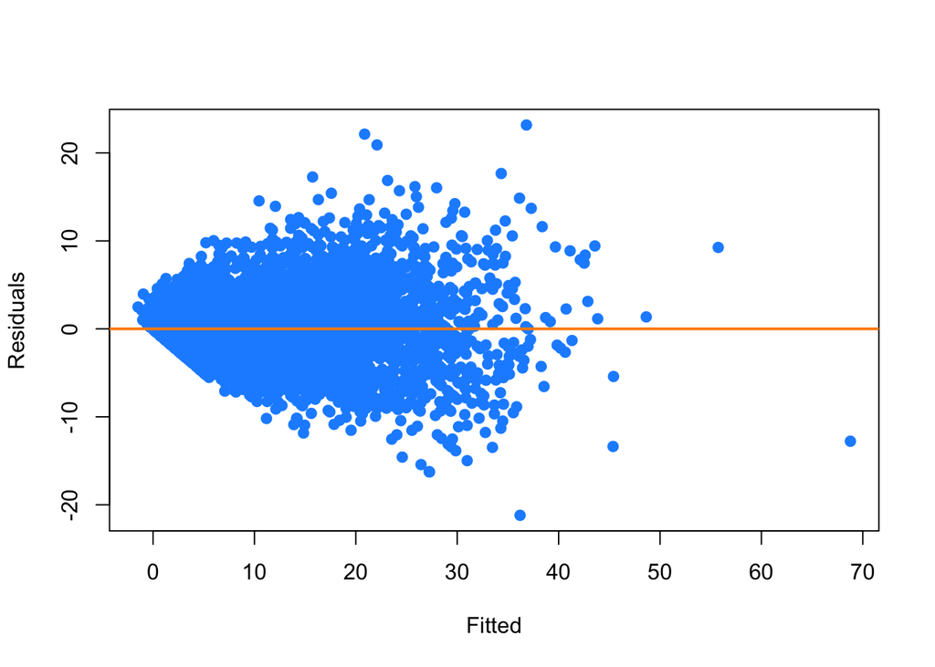

```r
plot_fitted_resid(goals_bigModel)
```

```r
bptest(goals_bigModel)
```

```
##
##  studentized Breusch-Pagan test
##
## data:  goals_bigModel
## BP = 2209, df = 94, p-value <2e-16
```

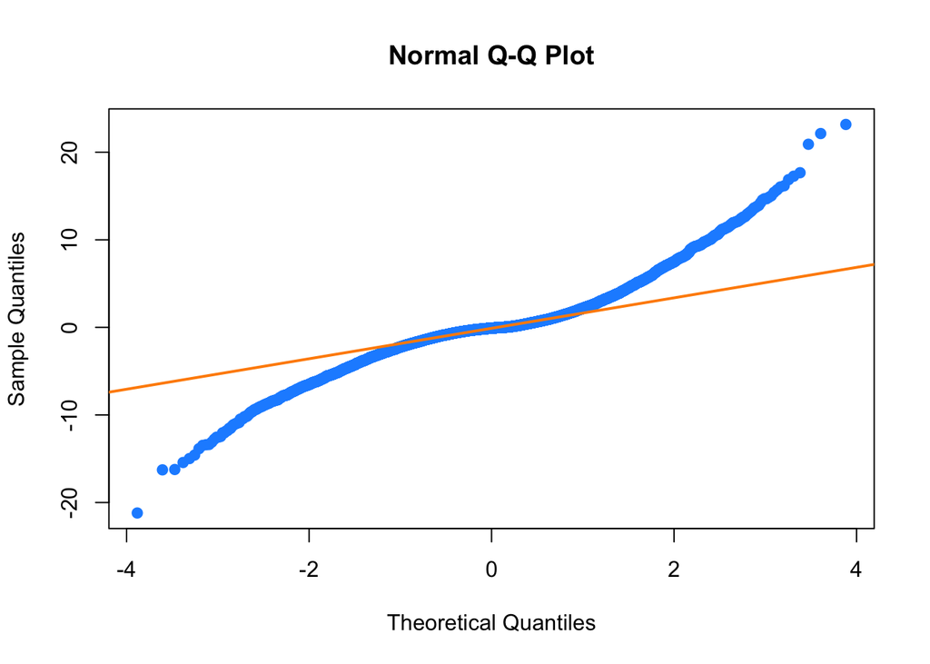

```r
plot_qq(goals_bigModel)
```

As we can see, our assumptions for constant variance and our assumptions for normality of errors have both been violated.

# Discussion

As we mentioned and displayed in the results section, the assumptions for both constant variance and normality of errors have both been violated. Based upon the residual graph, you can clearly see that it does not follow a constant variance and bubbles out during the middle-fitted values. We also further confirmed that constant variance is violated by utilizing the studentized Breusch-Pagan test. With its small p-value, we reject the null of homoscedasticity. Therefore, the constant variance is violated. Lastly, the Q-Q plot showed that the points did not closely follow the straight line. Therefore the model does violates the assumption of normality.

Some potential shortcomings we had with our model was the fact that some data were not tracked until much later. For instance, some of the data wasn’t tracked until 2008 which made it a little harder to do models. Another issue we faced when trying to run models was the fact that interaction models took a very long time to run.

# Appendix

The full additive model:

```r
goals_addfull = lm(G ~ ., data = skaters_cleaned)
summary(goals_addfull)$r.sq
```

```
## [1] 0.8434
```

In our analysis, we used backwards selection procedures with AIC as our metric, starting on the full additive model:

```r
goals_model_back_aic = step(goals_addfull, direction = "backward", trace = 0)
summary(goals_model_back_aic)$adj.r.sq
```

```
## [1] 0.8431
```

We also searched through the possible models using BIC; the code is included below but will not run when knitting together the .Rmd file, in order to maximize processing efficiency:

```r
n = length(resid(goals_addfull))
goals_model_back_bic = step(goals_addfull, direction = "backward", k = log(n))
summary(goals_model_back_bic)adj.$r.sq
```

We considered a polynomial model, with backwards AIC as well (not run to minimize the time taken to knit an html file):

```r
goals_bigModel = lm(G ~. ^ 2 + I(Age ^ 2)  + I(GP ^ 2) + I(A ^ 2) + I(PIM ^ 2) + I(S ^ 2) + I(BLK ^ 2) + I(FOwin ^ 2) + I(FOloss ^ 2), data = skaters_cleaned)
summary(goals_bigModel)$r.sq
big_model_back_aic = step(goals_bigModel, direction = "backward", trace = 0)
summary(big_model_back_aic)$r.sq
```

Code is not included here for concision, but all assumptions were violated when we attempted to check validity of the assumptions for constant variance and normality of errors, using a combination of the functions included in the **Methods** section and the `bptest()` function.

### Fall 2020, JMN420: Jeffrey Yao, Martha Dixon, Nisha Sen